# Week 10 - Gene clustering in R

### Objectives

By the end of this lab, you should be able to:

- Understand the concepts of clustering and dimensionality reduction
- Use existing R libraries to generate heatmaps and visualize gene expression data.

This week we’ll look a bit more carefully at heatmaps, which apply hierarchical clustering to visualise gene expression data.

In order to visualise the data effectively, we’ll also look at some more useful built-in R functions for manipulating data frames and matrices.

### Reminders

You can use `help()` or the `?` operator to get help on any function in R. This also works on many libraries once they are loaded.

To get help on an R operator or R keyword, you can put it in backquotes, e.g. `` help(`+`) `` or `` ?`if` ``.

To see a small part of a large variable like a matrix or data frame, try `head()`.

Data frames and matrices can both be indexed with syntax like `X[rows, columns]`. The rows and columns you want can be specified in several ways, including:

- Numerical vectors specifying which rows/columns we want, e.g. `alldata[1:3,1:10]`
- Logical (TRUE/FALSE) vectors. These will return any rows/columns corresponding to TRUE values in the vector. For instance, `alldata[alldata$chromosome_name == "Y",]` returns rows where the chromosome name is Y.
- Names of columns or rows. The count for patient M00103_M, gene ENSG00000156639, can be retrieved with `alldata["ENSG00000156639","M00103_M"]`

### Data and libraries

In this lab we will use data that has been made available as the R package breastCancerNKI in Bioconductor. To install all the packages we’ll need, run:

```r
source("http://bioconductor.org/biocLite.R")
biocLite("breastCancerNKI")
biocLite("Biobase")
install.packages("gplots")
```

Once installed, use the `library()` command to load each of these packages into your R session.

The `heatmap()` function we will use is already available as part of the `stats` package, but `gplots` gives us access to the more flexible `heatmap.2()` function.

### Heatmaps and dendrograms: toy example

Let’s illustrate heatmaps with an example that’s easy to see. Paste in this code to create a small matrix:

```r
# Create a 4x3 matrix by specifying 4 rows
# Values will be filled in column by column
M = matrix(c(9,3,4,7,5,8,9,4,8,4,2,11), 4)

# Give names to the rows and columns
rownames(M) = c("Gene1","Gene2","Gene3","Gene4")
colnames(M) = c("Sample1","Sample2","Sample3")
M
```

```
##       Sample1 Sample2 Sample3
## Gene1       9       5       8
## Gene2       3       8       4
## Gene3       4       9       2
## Gene4       7       4      11
```

First, try the `image()` function. This converts values in the matrix to blocks of colour, like a heatmap, but it performs no clustering. Run

```r
image(M)
```

Compare this to the `heatmap()` function:

```r
heatmap(M)
```

If necessary, you can widen the image margins around the heatmap with the `margins` parameter. This parameter expects a 2-element vector with the desired x and y margin sizes, e.g.

```r
heatmap(M, margins=c(10,8))
```

Observe the dendrograms for samples and genes, and notice the reordering of rows and columns.

Notice that the row and column names of the matrix are used in the plot (reordered by clustering). You can use `rownames()` and `colnames()` on your data to alter the names displayed for your data.

Also note that this is unsupervised learning - although we didn’t assign samples to categories or carry out any kind of differential expression analysis, it’s pretty clear from the clustering that there are two different patterns of expression.

Check the documentation for this function with `help(heatmap)`. Some interesting paramters to note are:

- `hclustfun`, which selects which function to use for clustering. It defaults to `hclust()`. This function can apply a chosen linkage method for hierarchical clustering - check `help(hclust)`; what is the default linkage method?
- `distfun`, which selects which function to use to calculate distances between samples. It defaults to `dist()` - use `help(dist)` to see the available distance metrics.

For instance, if we apply the default (Euclidean) distance function to our expression array M:

```r
dist(M)
```

[output not shown]

This tells us how similar (or distant) genes are. If we want to know how similar samples are, we can take the transpose of the matrix:

```r
dist(t(M))
```

```
##           Sample1   Sample2
## Sample2  8.660254
## Sample3  4.690416 11.090537
```

You can directly visualise the clustering results with `plot()`, which allows you to quickly try out different distance metrics and linkage methods. For example:

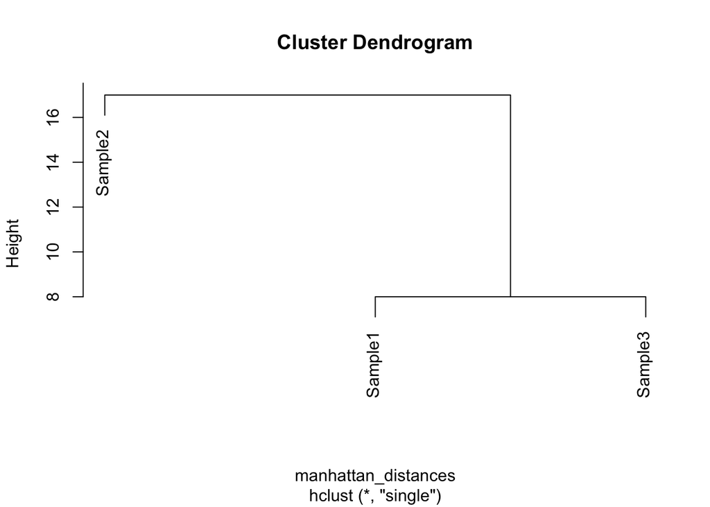

```r
manhattan_distances = dist(t(M), method="manhattan")
plot(hclust(manhattan_distances, method="single"))
```

You can also try `heatmap.2()`, an enhanced version of the heatmap function, provided by the gplots package. The two functions have different defaults for the distance metric and the linkage method, and different default behaviours for normalising the values.

### Load and explore data

Next we’ll load some real data, which will require a bit more work to cluster effectively.

The `breastCancerNKI` package contains gene expression data from a breast cancer study. You can use `library(help=breastCancerNKI)` to see some information on the source of the data. If you are interested, the original paper on this data by van’t Veer et al. is [here](http://www.nature.com/nature/journal/v415/n6871/full/415530a.html).

You can see a list of available datasets with the `data()` command. If you’ve loaded the breastCancerNKI library, you should see the dataset `nki` available. Load it with `data(nki)`, and you should see it appear as a variable in your environment. In RStudio, this is in the Environment window, and you can also see defined variables using `ls()`.

If you try the structure function `str()`, you’ll see that `nki` is quite a complicated object! It’s actually an S4 class in R, of type ExpressionSet. We won’t cover S4 classes - they are an advanced topic. We’ll just use functions from the Biobase library which know how to extract the data we want from ExpressionSet variables.

Here are some Biobase functions to try out on `nki`:

- `exprs(nki)` - get the expression matrix. This is the most important data for this workshop! You’ll probably want to assign it to a variable for convenient use.
- `featureNames(nki)` - get the feature (e.g. gene) names
- `experimentData(nki)` - display the experiment information
- `abstract(nki)` - display the abstract for this dataset
- `pData(nki)` - phenotype information for each sample (for instance, tumour grade)

If you like, you can use `library(help=Biobase)` to see a list of all Biobase functions.

**Exercise:** Assign the expression matrix to a variable and use `dim()` to see how many genes and samples there are.

### Find the most variable genes

We’ll try to include those genes whose expression values vary the most across all samples (this is not as sophisticated as doing DGE, which gives us genes which vary between categories).

#### Filtering and missing data

**Stop and think:** Would it make sense to filter our genes? Last week we filtered probes which had low expression values in *both* groups (men and women), since these were not likely to be useful. Here, we are doing clustering, so we don’t know in advance which groups to check, or even how many groups there will be.

The other thing we might want to filter on is missing data. Some values in our expression array are unknown; these have the special R value `NA`. Given an array `all_expr`, we can find missing values with

```r
is.na(all_expr)
```

Try this on your own expression array variable.

We can count how many `TRUE` values there are (and hence how many `NA`s there were) with `sum()`, which will treat `TRUE` as `1` and `FALSE` as `0`:

```r
sum(is.na(all_expr))
```

```
## [1] 54262
```

This isn’t too many compared to the size of the data. The `heatmap()` function can cope with missing data, so in the interests of time we will *not* do any filtering. But, bear in mind that filtering out probes with large numbers of missing values might be a good idea, as their apparent variance could be misleading.

#### Calculate variances

We can find the variance of set of numbers with the `var()` function. Try for yourself to use indexing to get the top row of the expression matrix, i.e. the expression values for a single gene, and apply `var()` to this row. Note that you will probably have to use the `na.rm=TRUE` parameter of `var()` to ignore missing values.

```r
variances = apply(all_expr, 1, var, na.rm=TRUE)
```

The extra argument here, `na.rm=TRUE`, just gets passed in to `var()`, so that `var()` will ignore missing values.

#### Sort matrix to get top genes

We’ll try to take the 50 most variable genes.

One way to do this is to sort the genes by variance, and then just take the first 50 rows.

Sorting in R is usually done with the `order()` function. This function returns a vector telling you where each item should go in order to be sorted. This looks a bit indirect the first time you see it. Here’s an example to illustrate. We’ll make a data frame, then try to sort it alphabetically.

```r
# Make a data frame to illustrate
numbers = c(1,3,5,7,11,13,15)
words = c("one","three","five","seven","eleven","thirteen","fifteen")
oddtable = data.frame(numbers, words)
oddtable
```

```
##   numbers    words
## 1       1      one
## 2       3    three
## 3       5     five
## 4       7    seven
## 5      11   eleven
## 6      13 thirteen
## 7      15  fifteen
```

```r
# Use order to sort alphabetically
# This tells us where each row *should* be
order( oddtable$words )
```

```
## [1] 5 7 3 1 4 6 2
```

Try to understand what you got from the `order()` function here!

```r
# Use this ordering as a vector to index the rows.
# This pull out rows in the order we want, giving a rearranged table
row_order = order( oddtable$words )
sorted_oddtable = oddtable[row_order,]
sorted_oddtable
```

```
##   numbers    words
## 5      11   eleven
## 7      15  fifteen
## 3       5     five
## 1       1      one
## 4       7    seven
## 6      13 thirteen
## 2       3    three
```

If we now wanted the top four of our numbers ordered alphabetically, we could just use

```r
sorted_oddtable[1:4,]
```

```
##   numbers   words
## 5      11  eleven
## 7      15 fifteen
## 3       5    five
## 1       1     one
```

**Exercise:** Using the variances you calculated with `apply()` and `var()`, now use `order()` on the resulting variances to sort the expression matrix and get the 50 most variable genes. Notice that `order()` sorts in ascending order by default, so you’ll probably want to tell it to sort in descending order instead.

### Draw the heatmap

Once we’ve filtered the data, drawing the heatmap is pretty simple. Use the `heatmap()` or `heatmap.2()` function, as you prefer. Make sure to use your top 50 genes only, try not to accidentally run `heatmap()` on your entire expression matrix - this may freeze R!

If you use `heatmap.2()`, use the parameter `trace="none"` to prevent overly-dense trace lines being drawn over the top of your heatmap.

You will probably find that the default red-yellow colour scheme is not very clear. Remember you can change the colours used with the `col` parameter in the `heatmap()` function (e.g. `heatmap(M, col=bluered(75)`). There are a couple of functions to create different colour schemes in R (some of which are equivalent). Last week we used the `colorRampPalette()` function. Other convenient options include:

- `colorpanel()`: e.g. `colorpanel(75, "blue", "lightyellow", "red")` will give a palette of 75 colours from blue through light yellow to red, with light yellow representing zero.
- convenience aliases which just take a number - e.g. try `redgreen(75)`, `greenred(75)`, `bluered(75)` and `redblue(75)`.

Some good hints on modifying your heatmap for better visualisation can be found in this post: http://www2.warwick.ac.uk/fac/sci/moac/people/students/peter_cock/r/heatmap/ .

**Advanced**

Note the `ColSideColors` parameter used in the above blog post, used to add a banner bar to the heatmap. We can use this to compare the (unsupervised) clustering to known labels. You might want to try this with the tumour grade from the phenotype information (`pData(nki)`), or other phenotype variables.

### Optional: changing the linkage method

`heatmap()` and `heatmap.2()` allow us to specify the function used for hierarchical clustering with the `hclustfun` parameter. It uses the `hclust()` function by default. `?hclust` tells us that the default linkage method is “complete” linkage, mentioned in lectures.

If we want to change this linkage method, we’d still like to use `hclust()`, but we want to specify a different parameter to it. Here’s a syntax that will do this, for example, for single linkage:

```r
hclust.single <- function(distmatrix) { hclust(distmatrix, method='single') }
heatmap(expr_matrix, hclustfun=hclust.single)
```

### Optional: K-means in R

K-means clustering in R is implemented in the `kmeans()` function, in the built-in stats package. Given a matrix, `kmeans()` will cluster the rows, treating each row as a vector (or point) in a space defined by the columns.

For instance, using the toy matrix `M` from the start of the lab:

```r
# Cluster genes into two groups, K=2
kmeans(M, 2)
```

```
## K-means clustering with 2 clusters of sizes 2, 2
##
## Cluster means:
##   Sample1 Sample2 Sample3
## 1     8.0     4.5     9.5
## 2     3.5     8.5     3.0
##
## Clustering vector:
## Gene1 Gene2 Gene3 Gene4
##     1     2     2     1
##
## Within cluster sum of squares by cluster:
## [1] 7 3
##  (between_SS / total_SS =  88.7 %)
##
## Available components:
##
## [1] "cluster"      "centers"      "totss"        "withinss"
## [5] "tot.withinss" "betweenss"    "size"         "iter"
## [9] "ifault"
```

```r
# Cluster samples into two groups (take the transpose of the matrix)
kmeans(t(M), 2)
```

```
## K-means clustering with 2 clusters of sizes 2, 1
##
## Cluster means:
##   Gene1 Gene2 Gene3 Gene4
## 1   8.5   3.5     3     9
## 2   5.0   8.0     9     4
##
## Clustering vector:
## Sample1 Sample2 Sample3
##       1       2       1
##
## Within cluster sum of squares by cluster:
## [1] 11  0
##  (between_SS / total_SS =  85.0 %)
##
## Available components:
##
## [1] "cluster"      "centers"      "totss"        "withinss"
## [5] "tot.withinss" "betweenss"    "size"         "iter"
## [9] "ifault"
```

The “Clustering vector” shows which cluster each item has been assigned to.

Since this toy data had a very clear distinction between groups, we get the same groupings from K-means as we did for hierarchical clustering.

If you try `kmeans()` on the real expression data, you will find it complains about missing values. We could filter our data, or fill in missing values with a command like `all_expr[ is.na(all_expr) ] = 0` (note that this is a pretty crude way to fill in missing data!).

You can also try using more specific packages for clustering. For instance, try

```r
library('cluster')
help(`clara`)
```

`clara()` actually performs k-medoids clustering, and can handle missing values, as well as large datasets.

### Python

If you’re interested in using these same algorithms in Python, K-means and hierarchical clustering implementations can be found in the scikit-learn module (http://scikit-learn.org/), under **sklearn.cluster**. Straighforward versions of these algorithms are also not too hard to implement!

.